# Who Gets Power First? A Classification Model

## Part 3: Feature Engineering for Classification

The features that matter for classification are different from regression. For regression, you wanted features that predicted *how much* demand would be. For classification, you want features that reveal *what kind* of building this is.

Think about what distinguishes a Critical building from a Non-Critical one:

- Critical buildings run at high demand **around the clock** — low variability
- Non-Critical buildings have **peaks and valleys** — high variability
- Flexible buildings are somewhere in between

Your features need to capture that behavioral signature.

```python
# Feature 1: variability_ratio (already in dataset as global_std_kWh / global_mean_kWh)
# Hospitals run 24/7 — low variability
# Restaurants peak at meal times — high variability
# This ratio captures operational pattern better than raw demand

df['variability_ratio'] = df['global_std_kWh'] / (df['global_mean_kWh'] + 1e-6)

# Verify — Critical buildings should have LOWER variability
print("Average variability ratio by tier:")
print(df.groupby('priority_tier')['variability_ratio'].mean().round(3))
print("\nDoes lower variability = more Critical? (should be yes)")
```

```
Average variability ratio by tier:
priority_tier
Critical        0.207
Flexible        0.298
Non_Critical    0.241
Name: variability_ratio, dtype: float64

Does lower variability = more Critical? (should be yes)
```

```python
# Feature 2: overnight_demand_ratio
# Critical buildings (hospitals) maintain HIGH demand overnight
# Non-critical buildings (restaurants, shops) go quiet at night
# This feature captures whether a building is truly 24/7 or business-hours only

# YOUR CODE: Create a column that is 1 if hour is between 22 and 6 (overnight), else 0
# Hint: use (df['hour'] >= 22) | (df['hour'] <= 6)
# then compare energy_kWh to global_mean_kWh during overnight hours

df['is_overnight'] = (df['hour'] >= 22) | (df['hour'] <= 6)

# Given: compute overnight demand ratio per building
overnight_mean = df[df['is_overnight'] == 1].groupby('building_type')['energy_kWh'].mean()
df['overnight_mean_kWh'] = df['building_type'].map(overnight_mean)
df['overnight_demand_ratio'] = df['overnight_mean_kWh'] / (df['global_mean_kWh'] + 1e-6)

# Justification (one sentence — why does overnight behavior help classify priority?):
#

print("Average overnight demand ratio by tier:")
print(df.groupby('priority_tier')['overnight_demand_ratio'].mean().round(3))
print("\nHospitals should have ratio near 1.0 (demand stays high overnight)")
print("Restaurants should have ratio well below 1.0 (quiet overnight)")
```

```
Average overnight demand ratio by tier:
priority_tier
Critical        0.841
Flexible        0.718
Non_Critical    0.772
Name: overnight_demand_ratio, dtype: float64

Hospitals should have ratio near 1.0 (demand stays high overnight)
Restaurants should have ratio well below 1.0 (quiet overnight)
```

```python
# Feature 3: peak_to_baseline_ratio
# How much does demand spike above its own baseline?
# Critical buildings have small spikes — they're always running hard
# Non-critical buildings have large spikes — busy periods vs quiet periods

# YOUR CODE: Create peak_to_baseline_ratio
# Formula: global_max_kWh divided by global_mean_kWh
# Example pattern: df['col'] = df['col_a'] / (df['col_b'] + 1e-6)

df['peak_to_baseline_ratio'] = df['global_max_kWh'] / (df['global_mean_kWh'] + 1e-6)

# Justification (one sentence):
# Divides glabal max over the global mean to calculate the baseline, the 1e-6 adds a tiny decimal to prevent division by 0

print("Average peak-to-baseline ratio by tier:")
print(df.groupby('priority_tier')['peak_to_baseline_ratio'].mean().round(3))
print("\nLower ratio = more stable = more likely Critical")
```

```
Average peak-to-baseline ratio by tier:
priority_tier
Critical        1.369
Flexible        1.474
Non_Critical    1.417
Name: peak_to_baseline_ratio, dtype: float64

Lower ratio = more stable = more likely Critical
```

```python
# Exercise 3.1 — Design your own classification feature
# Create ONE feature that captures something the above features miss.
#
# Ideas:
#   - business_hours_intensity: ratio of business-hours demand to overnight demand
#   - demand_rank: rank each building by mean demand (1=highest)
#   - is_24_7: binary flag for buildings that never drop below 80% of their mean
#   - weekend_drop: how much demand falls on weekends vs weekdays
#
# Example patterns:
#   df['col'] = df['col_a'] / df['col_b']           # ratio
#   df['col'] = (df['col_a'] > threshold).astype(int) # binary flag
#   df['col'] = df['col_a'].rank(pct=True)            # percentile rank

# Feature name: (rename 'my_class_feature' to something descriptive)
# YOUR CODE:
df['demand_rank'] = (df.groupby('hour')['global_mean_kWh'].rank(ascending=False, method='min')).astype(int)

# Why did you create this feature? What behavioral pattern does it capture?
# JUSTIFICATION: This feature will help determine how to spread power within each tier, it captures the power usage ranking per time mark, helping the model classify where to distrubute power.
#

print("Demand rank by tier:")
print(df.groupby('priority_tier')['demand_rank'].mean().round(3))
print("\nDoes this feature separate the tiers? Does the direction make sense?")
```

```
Demand rank by tier:
priority_tier
Critical        20.504
Flexible        24.320
Non_Critical    16.635
Name: demand_rank, dtype: float64

Does this feature separate the tiers? Does the direction make sense?
```

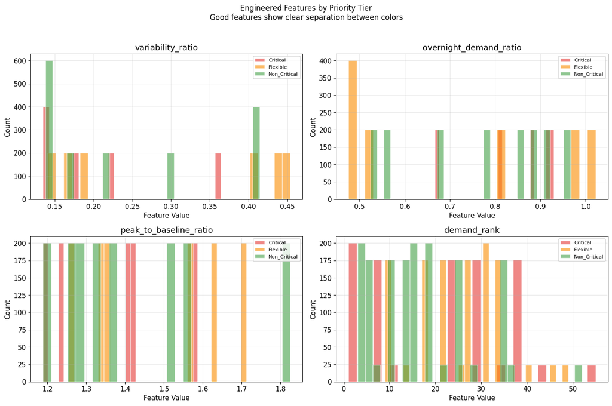

```python
# Visualize your engineered features
# Do they actually separate the tiers visually?

eng_features = ['variability_ratio', 'overnight_demand_ratio',
                'peak_to_baseline_ratio', 'demand_rank']

fig, axes = plt.subplots(2, 2, figsize=(14, 9))
axes = axes.flatten()

for i, feat in enumerate(eng_features):
    for tier, color in TIER_COLORS.items():
        tier_data = df[df['priority_tier'] == tier][feat].dropna()
        axes[i].hist(tier_data, bins=30, color=color, alpha=0.6,
                     edgecolor='white', label=tier)
    axes[i].set_title(feat)
    axes[i].set_xlabel('Feature Value')
    axes[i].set_ylabel('Count')
    axes[i].legend(fontsize=8)

plt.suptitle('Engineered Features by Priority Tier\n'
             'Good features show clear separation between colors',
             fontsize=12, y=1.02)
plt.tight_layout()
plt.show()
```

## Part 4: Feature Selection and Model Training

A **decision tree** classifies by asking a series of yes/no questions about your features. At each branch it asks the question that best separates the classes — like a flowchart that the data taught itself.

Decision trees are interpretable — you can read the rules the model learned and ask *does this make sense?* That matters enormously when the model's decisions affect who gets power during an emergency.

```python
# Exercise 4.1 — YOUR FEATURE SELECTION
# Choose which features to include. You must include at least 4.
# Write your reasoning for each included AND excluded feature.
#
# Available features:
# 'energy_kWh', 'global_mean_kWh', 'global_max_kWh', 'global_std_kWh',
# 'hour', 'is_business_hours', 'pct_of_daily_max',
# 'variability_ratio', 'overnight_demand_ratio',
# 'peak_to_baseline_ratio', 'demand_rank'

# FEATURES WE ARE INCLUDING AND WHY:
# 1. global_mean_kWh     — because: Gives model the average
# 2. global_std_kWh      — because: Gives model average deviation
# 3. variability_ratio   — because: Gives model a sense of how much fluctuation is needed
# 4. hour                — because: its the timestamp
# 5. energy_kWh          — because: Raw ewnergy data
# 6. is_business_hours   - because: gives an boost during buisness hours
# 7. pct_of_daily_max    - because: helps predict how much more is needed
# 8. demand_rank         - becuase: helps spread power to individuals rather than tier


# FEATURES WE ARE EXCLUDING AND WHY:
# 1. global_max_kWh      — because: Taken care of by variability ratio
# 2. overnight_demand_ratio — because: taken care of by hour and business hours
# 3. peak_to_baseline_ratio - because: taken care of by the daily max

selected_features = [
    'global_mean_kWh',
    'global_std_kWh',
    'variability_ratio',
    'hour',
    'energy_kWh',
    'is_business_hours',
    'pct_of_daily_max',
    'demand_rank'
    # ADD MORE FEATURE NAMES HERE AS STRINGS
]

X = df[selected_features].fillna(0)
y = df['priority_tier']

print(f"Selected {len(selected_features)} features: {selected_features}")
print(f"X shape: {X.shape}")
print(f"\nClass distribution:")
print(y.value_counts())
```

```
Selected 8 features: ['global_mean_kWh', 'global_std_kWh', 'variability_ratio', 'hour', 'energy_kWh', 'is_business_hours', 'pct_of_daily_max', 'demand_rank']
X shape: (3800, 8)

Class distribution:
priority_tier
Non_Critical    1600
Flexible        1200
Critical        1000
Name: count, dtype: int64
```

```python
# Train / test split — stratified to preserve class balance
X_train, X_test, y_train, y_test = train_test_split(
    X, y, test_size=0.2, random_state=42, stratify=y
)

print(f"Training rows: {len(X_train):,}")
print(f"Test rows:     {len(X_test):,}")
print(f"\nClass balance in test set:")
print(y_test.value_counts())
print(f"\nNote: stratify=y ensures each class is proportionally represented")
print(f"in both training and test sets. Without this, rare classes could")
print(f"be underrepresented in training — the model would never learn them.")
```

```
Training rows: 3,040
Test rows:     760

Class balance in test set:
priority_tier
Non_Critical    320
Flexible        240
Critical        200
Name: count, dtype: int64

Note: stratify=y ensures each class is proportionally represented
in both training and test sets. Without this, rare classes could
be underrepresented in training — the model would never learn them.
```

```python
# Exercise 4.2 — Choose your tree depth
# max_depth controls how many questions the tree can ask.
# Shallow trees (depth 2-3) are simple but may miss patterns.
# Deep trees (depth 8+) may memorize training data but fail on new data.
#
# Try at least TWO different depths and compare results.
# Choose the depth you will use for your final model and justify it.

# YOUR DEPTH EXPERIMENTS:
for depth in [3, 6, 8]:
    dt_temp = DecisionTreeClassifier(max_depth=depth, random_state=42)
    dt_temp.fit(X_train, y_train)
    train_acc = accuracy_score(y_train, dt_temp.predict(X_train))
    test_acc  = accuracy_score(y_test,  dt_temp.predict(X_test))
    print(f"max_depth={depth}: train={train_acc:.3f}  test={test_acc:.3f}  "
          f"gap={train_acc-test_acc:.3f}")

print()
print("A large gap between train and test accuracy suggests overfitting.")
print("Your chosen depth and reasoning:")
# CHOSEN DEPTH: 6
# REASONING: 3 has too large a gap, and the gap of 0 for 8 seems way to suspiscious, so I'm choosing 6, its the best split that still has a gap and isn't suspicously perfect.
```

```
max_depth=3: train=0.739  test=0.726  gap=0.013
max_depth=6: train=0.949  test=0.942  gap=0.007
max_depth=8: train=1.000  test=1.000  gap=0.000

A large gap between train and test accuracy suggests overfitting.
Your chosen depth and reasoning:
```

```python
# Train your final model
# Replace 5 with your chosen depth from the experiment above
CHOSEN_DEPTH = 6   # REPLACE WITH YOUR CHOSEN DEPTH

model = DecisionTreeClassifier(max_depth=CHOSEN_DEPTH, random_state=42)
model.fit(X_train, y_train)

print(f"Decision tree trained (max_depth={CHOSEN_DEPTH})")
print(f"\nWhat the model learned — feature importances:")
print("-" * 45)
for feat, imp in sorted(zip(selected_features, model.feature_importances_),
                         key=lambda x: x[1], reverse=True):
    bar = '█' * int(imp * 30)
    print(f"{feat:<28} {imp:.3f}  {bar}")
```

```
Decision tree trained (max_depth=6)

What the model learned — feature importances:
---------------------------------------------
variability_ratio            0.434  █████████████
global_mean_kWh              0.360  ██████████
demand_rank                  0.111  ███
global_std_kWh               0.096  ██
hour                         0.000
energy_kWh                   0.000
is_business_hours            0.000
pct_of_daily_max             0.000
```

```python
# Read the decision tree rules
# This is what makes decision trees powerful for high-stakes decisions:
# you can read exactly what the model is doing and ask if it makes sense

tree_rules = export_text(model, feature_names=selected_features)
print("Decision Tree Rules:")
print("(Each branch is a yes/no question. Follow the path to get a classification.)")
print("-" * 60)
print(tree_rules)
```

```
Decision Tree Rules:
(Each branch is a yes/no question. Follow the path to get a classification.)
------------------------------------------------------------
|--- variability_ratio <= 0.43
|   |--- global_mean_kWh <= 11.49
|   |   |--- global_mean_kWh <= 6.67
|   |   |   |--- global_mean_kWh <= 2.81
|   |   |   |   |--- class: Critical
|   |   |   |--- global_mean_kWh >  2.81
|   |   |   |   |--- class: Non_Critical
|   |   |--- global_mean_kWh >  6.67
|   |   |   |--- variability_ratio <= 0.14
|   |   |   |   |--- class: Critical
|   |   |   |--- variability_ratio >  0.14
|   |   |   |   |--- class: Flexible
|   |--- global_mean_kWh >  11.49
|   |   |--- global_std_kWh <= 1.60
|   |   |   |--- class: Critical
|   |   |--- global_std_kWh >  1.60
|   |   |   |--- demand_rank <= 2.00
|   |   |   |   |--- class: Critical
|   |   |   |--- demand_rank >  2.00
|   |   |   |   |--- global_mean_kWh <= 56.62
|   |   |   |   |   |--- variability_ratio <= 0.15
|   |   |   |   |   |   |--- class: Non_Critical
|   |   |   |   |   |--- variability_ratio >  0.15
|   |   |   |   |   |   |--- class: Non_Critical
|   |   |   |   |--- global_mean_kWh >  56.62
|   |   |   |   |   |--- variability_ratio <= 0.38
|   |   |   |   |   |   |--- class: Critical
|   |   |   |   |   |--- variability_ratio >  0.38
|   |   |   |   |   |   |--- class: Non_Critical
|--- variability_ratio >  0.43
|   |--- class: Flexible
```

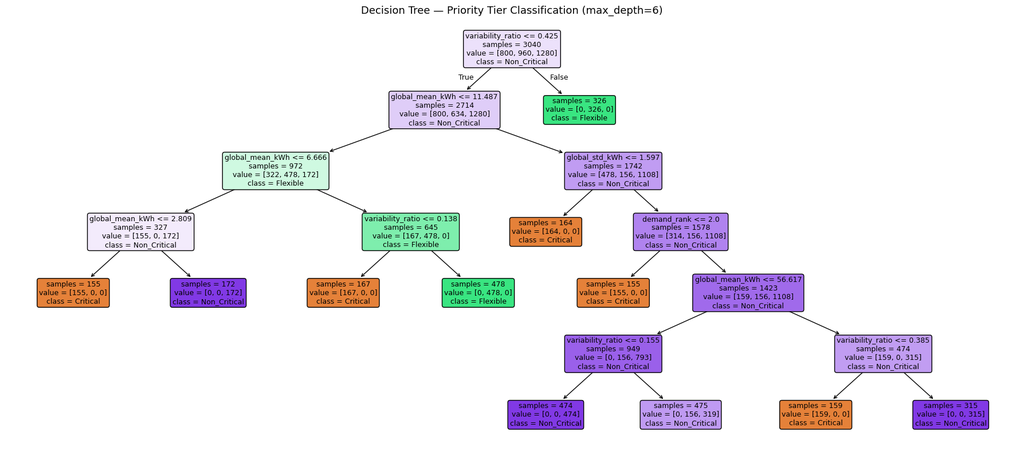

```python
# Visualize the tree — the painter's view of the model's logic
fig, ax = plt.subplots(figsize=(18, 8))
plot_tree(
    model,
    feature_names=selected_features,
    class_names=model.classes_,
    filled=True,
    rounded=True,
    fontsize=9,
    ax=ax,
    impurity=False
)
ax.set_title(f'Decision Tree — Priority Tier Classification (max_depth={CHOSEN_DEPTH})',
             fontsize=13)
plt.tight_layout()
plt.show()
```

```python
# Exercise 4.3 — Reading the tree

# Q1: What is the FIRST question the tree asks (the root node)?
#     Does that make intuitive sense as the most important distinguishing factor?
# A: Is the variability ratio less than or equal to 0.425, this makes sense as most critical buildings have a low variability.

# Q2: Which feature has the highest importance score?
#     Does that match your hypothesis from the Drawing with Data notebook?
# A: The variability ratio. no, I predicted hour would be the strongest

# Q3: Trace the path for a hospital:
#     global_mean_kWh ≈ 492, global_std_kWh ≈ 88, variability_ratio ≈ 0.18
#     Follow the tree rules above — which tier does the model assign it?
#     Is that correct?
# A: It assigns it critical, which is correct

# Q4: Could you explain this tree's logic to a city council member
#     who has no data science background? Try in 2-3 sentences.
# A: The tree starts by filtering out major flexible sources with the variability ratio, buildings that pass this are sorted based on mean consumption, less than or more than ~11.
# It continues filtering by either mean_kWh, variability ratio, or the demand rank.
```